# Risk Factor Analysis

## Outcome Variable

**Outcome Variable:** sstunted

## Predictor Variables

**Intervention Variable:** vagbrth

**Adjustment Set:**

unadjusted

## Stratifying Variables

The analysis was stratified on these variable(s):

- agecat
- studyid
- country

## Data Summary

| agecat | studyid | country | vagbrth | sstunted | n_cell | n |
| --- | --- | --- | --- | --- | --- | --- |
| Birth | ki1000108-CMC-V-BCS-2002 | INDIA | 0 | 0 | 10 | 90 |
| Birth | ki1000108-CMC-V-BCS-2002 | INDIA | 0 | 1 | 1 | 90 |
| Birth | ki1000108-CMC-V-BCS-2002 | INDIA | 1 | 0 | 77 | 90 |
| Birth | ki1000108-CMC-V-BCS-2002 | INDIA | 1 | 1 | 2 | 90 |
| Birth | ki1000108-IRC | INDIA | 0 | 0 | 67 | 388 |
| Birth | ki1000108-IRC | INDIA | 0 | 1 | 1 | 388 |
| Birth | ki1000108-IRC | INDIA | 1 | 0 | 305 | 388 |
| Birth | ki1000108-IRC | INDIA | 1 | 1 | 15 | 388 |
| Birth | ki1017093c-NIH-Crypto | BANGLADESH | 0 | 0 | 1 | 19 |
| Birth | ki1017093c-NIH-Crypto | BANGLADESH | 0 | 1 | 0 | 19 |
| Birth | ki1017093c-NIH-Crypto | BANGLADESH | 1 | 0 | 18 | 19 |
| Birth | ki1017093c-NIH-Crypto | BANGLADESH | 1 | 1 | 0 | 19 |
| Birth | ki1119695-PROBIT | BELARUS | 0 | 0 | 1596 | 13884 |
| Birth | ki1119695-PROBIT | BELARUS | 0 | 1 | 1 | 13884 |
| Birth | ki1119695-PROBIT | BELARUS | 1 | 0 | 12283 | 13884 |
| Birth | ki1119695-PROBIT | BELARUS | 1 | 1 | 4 | 13884 |
| Birth | ki1126311-ZVITAMBO | ZIMBABWE | 0 | 0 | 1133 | 13716 |
| Birth | ki1126311-ZVITAMBO | ZIMBABWE | 0 | 1 | 29 | 13716 |
| Birth | ki1126311-ZVITAMBO | ZIMBABWE | 1 | 0 | 12150 | 13716 |
| Birth | ki1126311-ZVITAMBO | ZIMBABWE | 1 | 1 | 404 | 13716 |
| Birth | kiGH5241-JiVitA-3 | BANGLADESH | 0 | 0 | 4 | 39172 |
| Birth | kiGH5241-JiVitA-3 | BANGLADESH | 0 | 1 | 2 | 39172 |
| Birth | kiGH5241-JiVitA-3 | BANGLADESH | 1 | 0 | 35088 | 39172 |
| Birth | kiGH5241-JiVitA-3 | BANGLADESH | 1 | 1 | 4078 | 39172 |
| Birth | kiGH5241-JiVitA-4 | BANGLADESH | 0 | 0 | 2 | 1644 |
| Birth | kiGH5241-JiVitA-4 | BANGLADESH | 0 | 1 | 0 | 1644 |
| Birth | kiGH5241-JiVitA-4 | BANGLADESH | 1 | 0 | 1514 | 1644 |
| Birth | kiGH5241-JiVitA-4 | BANGLADESH | 1 | 1 | 128 | 1644 |
| 6 months | ki1000108-CMC-V-BCS-2002 | INDIA | 0 | 0 | 23 | 369 |
| 6 months | ki1000108-CMC-V-BCS-2002 | INDIA | 0 | 1 | 2 | 369 |

[output cut: 70 more lines]

The following strata were considered:

- agecat: 24 months, studyid: ki1000108-CMC-V-BCS-2002, country: INDIA
- agecat: 24 months, studyid: ki1000108-IRC, country: INDIA
- agecat: 24 months, studyid: ki1017093b-PROVIDE, country: BANGLADESH
- agecat: 24 months, studyid: ki1017093c-NIH-Crypto, country: BANGLADESH
- agecat: 24 months, studyid: ki1066203-TanzaniaChild2, country: TANZANIA, UNITED REPUBLIC OF
- agecat: 24 months, studyid: ki1119695-PROBIT, country: BELARUS
- agecat: 24 months, studyid: ki1126311-ZVITAMBO, country: ZIMBABWE
- agecat: 24 months, studyid: kiGH5241-JiVitA-3, country: BANGLADESH
- agecat: 24 months, studyid: kiGH5241-JiVitA-4, country: BANGLADESH
- agecat: 6 months, studyid: ki1000108-CMC-V-BCS-2002, country: INDIA
- agecat: 6 months, studyid: ki1000108-IRC, country: INDIA
- agecat: 6 months, studyid: ki1017093b-PROVIDE, country: BANGLADESH
- agecat: 6 months, studyid: ki1017093c-NIH-Crypto, country: BANGLADESH
- agecat: 6 months, studyid: ki1066203-TanzaniaChild2, country: TANZANIA, UNITED REPUBLIC OF
- agecat: 6 months, studyid: ki1119695-PROBIT, country: BELARUS
- agecat: 6 months, studyid: ki1126311-ZVITAMBO, country: ZIMBABWE
- agecat: 6 months, studyid: kiGH5241-JiVitA-3, country: BANGLADESH
- agecat: 6 months, studyid: kiGH5241-JiVitA-4, country: BANGLADESH
- agecat: Birth, studyid: ki1000108-CMC-V-BCS-2002, country: INDIA
- agecat: Birth, studyid: ki1000108-IRC, country: INDIA
- agecat: Birth, studyid: ki1017093c-NIH-Crypto, country: BANGLADESH
- agecat: Birth, studyid: ki1119695-PROBIT, country: BELARUS
- agecat: Birth, studyid: ki1126311-ZVITAMBO, country: ZIMBABWE
- agecat: Birth, studyid: kiGH5241-JiVitA-3, country: BANGLADESH
- agecat: Birth, studyid: kiGH5241-JiVitA-4, country: BANGLADESH

### Dropped Strata

Some strata were dropped due to rare outcomes:

- agecat: Birth, studyid: ki1000108-CMC-V-BCS-2002, country: INDIA
- agecat: Birth, studyid: ki1000108-IRC, country: INDIA
- agecat: Birth, studyid: ki1017093c-NIH-Crypto, country: BANGLADESH
- agecat: Birth, studyid: ki1119695-PROBIT, country: BELARUS
- agecat: Birth, studyid: kiGH5241-JiVitA-3, country: BANGLADESH
- agecat: Birth, studyid: kiGH5241-JiVitA-4, country: BANGLADESH
- agecat: 6 months, studyid: ki1000108-CMC-V-BCS-2002, country: INDIA
- agecat: 6 months, studyid: ki1017093b-PROVIDE, country: BANGLADESH
- agecat: 6 months, studyid: ki1017093c-NIH-Crypto, country: BANGLADESH
- agecat: 6 months, studyid: ki1066203-TanzaniaChild2, country: TANZANIA, UNITED REPUBLIC OF
- agecat: 24 months, studyid: ki1000108-IRC, country: INDIA
- agecat: 24 months, studyid: ki1066203-TanzaniaChild2, country: TANZANIA, UNITED REPUBLIC OF

## Methods Detail

We’re interested in the causal parameters $E[Y_a]$ for all values of $a \in \mathcal{A}$. These parameters represent the mean outcome if, possibly contrary to fact, we intervened to set all units to have $A=a$. Under the randomization and positivity assumptions, these are identified by the statistical parameters $\psi_a=E_W[E_{Y|A,W}(Y|A=a,W)]$. In addition, we’re interested in the mean of $Y$, $E[Y]$ under no intervention (the observed mean). We will estimate these parameters by using SuperLearner to fit the relevant likelihood factors – $E_{Y|A,W}(Y|A=a,W)$ and $p(A=a|W)$, and then updating our likelihood fit using a joint TMLE.

For unadjusted analyses ($W=\{\}$), initial likelihoods were estimated using Lrnr_glm to estimate the simple $E(Y|A)$ and Lrnr_mean to estimate $p(A)$. For adjusted analyses, a small library containing Lrnr_glmnet, Lrnr_xgboost, and Lrnr_mean was used.

Having estimated these parameters, we will then use the delta method to estimate relative risks and attributable risks relative to a prespecified baseline level of $A$.

# Results Detail

## Results Plots

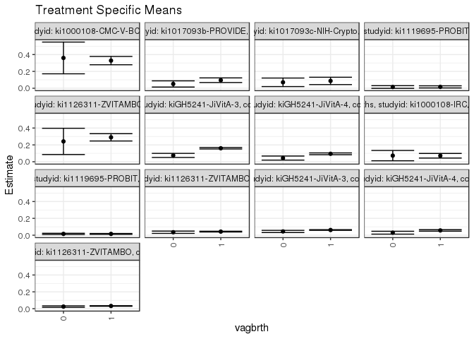

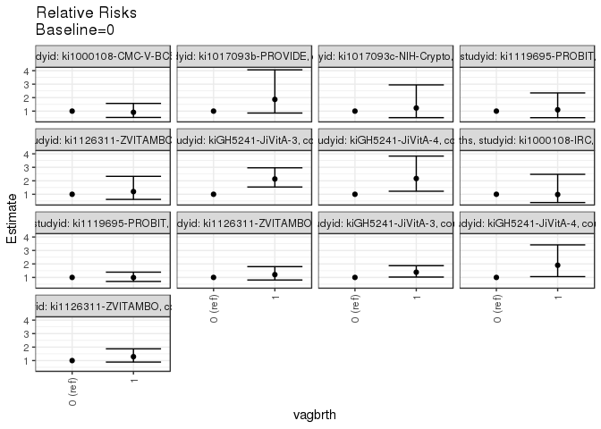

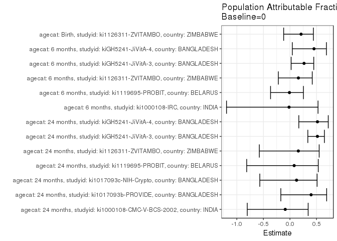

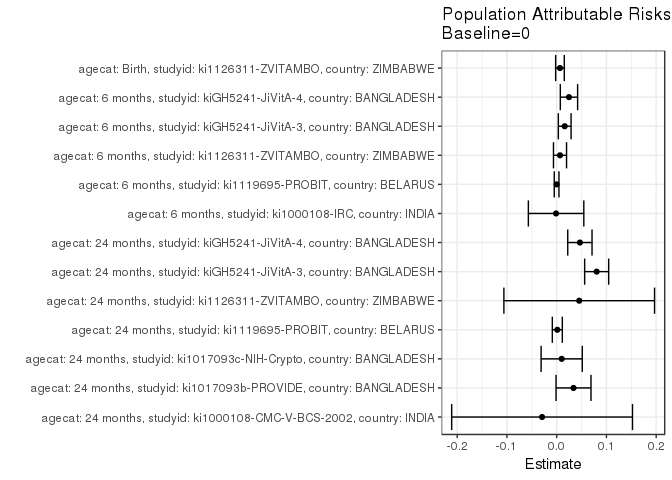

## Results Table

### Parameter: TSM

| agecat | studyid | country | intervention_level | baseline_level | estimate | ci_lower | ci_upper |
| --- | --- | --- | --- | --- | --- | --- | --- |
| Birth | ki1126311-ZVITAMBO | ZIMBABWE | 0 | NA | 0.0249570 | 0.0159875 | 0.0339265 |
| Birth | ki1126311-ZVITAMBO | ZIMBABWE | 1 | NA | 0.0321810 | 0.0290937 | 0.0352682 |
| 6 months | ki1000108-IRC | INDIA | 0 | NA | 0.0724638 | 0.0112169 | 0.1337106 |
| 6 months | ki1000108-IRC | INDIA | 1 | NA | 0.0710059 | 0.0435916 | 0.0984202 |
| 6 months | ki1119695-PROBIT | BELARUS | 0 | NA | 0.0155642 | 0.0081933 | 0.0229351 |
| 6 months | ki1119695-PROBIT | BELARUS | 1 | NA | 0.0153989 | 0.0100170 | 0.0207808 |
| 6 months | ki1126311-ZVITAMBO | ZIMBABWE | 0 | NA | 0.0353607 | 0.0217460 | 0.0489754 |
| 6 months | ki1126311-ZVITAMBO | ZIMBABWE | 1 | NA | 0.0426805 | 0.0381119 | 0.0472491 |
| 6 months | kiGH5241-JiVitA-3 | BANGLADESH | 0 | NA | 0.0445682 | 0.0315608 | 0.0575757 |
| 6 months | kiGH5241-JiVitA-3 | BANGLADESH | 1 | NA | 0.0617812 | 0.0577574 | 0.0658051 |
| 6 months | kiGH5241-JiVitA-4 | BANGLADESH | 0 | NA | 0.0298063 | 0.0129768 | 0.0466357 |
| 6 months | kiGH5241-JiVitA-4 | BANGLADESH | 1 | NA | 0.0567156 | 0.0477151 | 0.0657161 |
| 24 months | ki1000108-CMC-V-BCS-2002 | INDIA | 0 | NA | 0.3600000 | 0.1715900 | 0.5484100 |
| 24 months | ki1000108-CMC-V-BCS-2002 | INDIA | 1 | NA | 0.3285303 | 0.2790458 | 0.3780147 |
| 24 months | ki1017093b-PROVIDE | BANGLADESH | 0 | NA | 0.0510949 | 0.0141916 | 0.0879981 |
| 24 months | ki1017093b-PROVIDE | BANGLADESH | 1 | NA | 0.0954545 | 0.0679748 | 0.1229342 |
| 24 months | ki1017093c-NIH-Crypto | BANGLADESH | 0 | NA | 0.0707071 | 0.0201159 | 0.1212983 |
| 24 months | ki1017093c-NIH-Crypto | BANGLADESH | 1 | NA | 0.0869565 | 0.0433483 | 0.1305648 |
| 24 months | ki1119695-PROBIT | BELARUS | 0 | NA | 0.0148305 | -0.0010089 | 0.0306699 |
| 24 months | ki1119695-PROBIT | BELARUS | 1 | NA | 0.0162784 | 0.0034501 | 0.0291067 |
| 24 months | ki1126311-ZVITAMBO | ZIMBABWE | 0 | NA | 0.2413793 | 0.0854619 | 0.3972967 |
| 24 months | ki1126311-ZVITAMBO | ZIMBABWE | 1 | NA | 0.2897862 | 0.2464028 | 0.3331696 |
| 24 months | kiGH5241-JiVitA-3 | BANGLADESH | 0 | NA | 0.0750000 | 0.0506573 | 0.0993427 |
| 24 months | kiGH5241-JiVitA-3 | BANGLADESH | 1 | NA | 0.1601111 | 0.1511115 | 0.1691108 |
| 24 months | kiGH5241-JiVitA-4 | BANGLADESH | 0 | NA | 0.0434109 | 0.0192442 | 0.0675775 |
| 24 months | kiGH5241-JiVitA-4 | BANGLADESH | 1 | NA | 0.0941097 | 0.0832909 | 0.1049284 |

### Parameter: E(Y)

| agecat | studyid | country | intervention_level | baseline_level | estimate | ci_lower | ci_upper |
| --- | --- | --- | --- | --- | --- | --- | --- |
| Birth | ki1126311-ZVITAMBO | ZIMBABWE | NA | NA | 0.0315690 | 0.0286427 | 0.0344952 |
| 6 months | ki1000108-IRC | INDIA | NA | NA | 0.0712531 | 0.0462303 | 0.0962759 |
| 6 months | ki1119695-PROBIT | BELARUS | NA | NA | 0.0154178 | 0.0100323 | 0.0208033 |
| 6 months | ki1126311-ZVITAMBO | ZIMBABWE | NA | NA | 0.0420515 | 0.0377145 | 0.0463885 |
| 6 months | kiGH5241-JiVitA-3 | BANGLADESH | NA | NA | 0.0606731 | 0.0568223 | 0.0645238 |
| 6 months | kiGH5241-JiVitA-4 | BANGLADESH | NA | NA | 0.0544848 | 0.0460908 | 0.0628788 |
| 24 months | ki1000108-CMC-V-BCS-2002 | INDIA | NA | NA | 0.3306452 | 0.2827744 | 0.3785159 |
| 24 months | ki1017093b-PROVIDE | BANGLADESH | NA | NA | 0.0849220 | 0.0621566 | 0.1076874 |
| 24 months | ki1017093c-NIH-Crypto | BANGLADESH | NA | NA | 0.0807692 | 0.0475849 | 0.1139536 |
| 24 months | ki1119695-PROBIT | BELARUS | NA | NA | 0.0161090 | 0.0034156 | 0.0288025 |
| 24 months | ki1126311-ZVITAMBO | ZIMBABWE | NA | NA | 0.2866667 | 0.2448394 | 0.3284940 |
| 24 months | kiGH5241-JiVitA-3 | BANGLADESH | NA | NA | 0.1553483 | 0.1465904 | 0.1641062 |
| 24 months | kiGH5241-JiVitA-4 | BANGLADESH | NA | NA | 0.0900374 | 0.0798750 | 0.1001998 |

### Parameter: RR

| agecat | studyid | country | intervention_level | baseline_level | estimate | ci_lower | ci_upper |
| --- | --- | --- | --- | --- | --- | --- | --- |
| Birth | ki1126311-ZVITAMBO | ZIMBABWE | 0 | 0 | 1.0000000 | 1.0000000 | 1.000000 |
| Birth | ki1126311-ZVITAMBO | ZIMBABWE | 1 | 0 | 1.2894585 | 0.8889094 | 1.870498 |
| 6 months | ki1000108-IRC | INDIA | 0 | 0 | 1.0000000 | 1.0000000 | 1.000000 |
| 6 months | ki1000108-IRC | INDIA | 1 | 0 | 0.9798817 | 0.3869206 | 2.481564 |
| 6 months | ki1119695-PROBIT | BELARUS | 0 | 0 | 1.0000000 | 1.0000000 | 1.000000 |
| 6 months | ki1119695-PROBIT | BELARUS | 1 | 0 | 0.9893819 | 0.7033643 | 1.391706 |
| 6 months | ki1126311-ZVITAMBO | ZIMBABWE | 0 | 0 | 1.0000000 | 1.0000000 | 1.000000 |
| 6 months | ki1126311-ZVITAMBO | ZIMBABWE | 1 | 0 | 1.2070044 | 0.8093821 | 1.799965 |
| 6 months | kiGH5241-JiVitA-3 | BANGLADESH | 0 | 0 | 1.0000000 | 1.0000000 | 1.000000 |
| 6 months | kiGH5241-JiVitA-3 | BANGLADESH | 1 | 0 | 1.3862166 | 1.0268026 | 1.871437 |
| 6 months | kiGH5241-JiVitA-4 | BANGLADESH | 0 | 0 | 1.0000000 | 1.0000000 | 1.000000 |
| 6 months | kiGH5241-JiVitA-4 | BANGLADESH | 1 | 0 | 1.9028088 | 1.0603214 | 3.414702 |
| 24 months | ki1000108-CMC-V-BCS-2002 | INDIA | 0 | 0 | 1.0000000 | 1.0000000 | 1.000000 |
| 24 months | ki1000108-CMC-V-BCS-2002 | INDIA | 1 | 0 | 0.9125841 | 0.5293636 | 1.573228 |
| 24 months | ki1017093b-PROVIDE | BANGLADESH | 0 | 0 | 1.0000000 | 1.0000000 | 1.000000 |
| 24 months | ki1017093b-PROVIDE | BANGLADESH | 1 | 0 | 1.8681818 | 0.8585216 | 4.065248 |
| 24 months | ki1017093c-NIH-Crypto | BANGLADESH | 0 | 0 | 1.0000000 | 1.0000000 | 1.000000 |
| 24 months | ki1017093c-NIH-Crypto | BANGLADESH | 1 | 0 | 1.2298137 | 0.5133025 | 2.946492 |
| 24 months | ki1119695-PROBIT | BELARUS | 0 | 0 | 1.0000000 | 1.0000000 | 1.000000 |
| 24 months | ki1119695-PROBIT | BELARUS | 1 | 0 | 1.0976304 | 0.5128046 | 2.349418 |
| 24 months | ki1126311-ZVITAMBO | ZIMBABWE | 0 | 0 | 1.0000000 | 1.0000000 | 1.000000 |
| 24 months | ki1126311-ZVITAMBO | ZIMBABWE | 1 | 0 | 1.2005429 | 0.6186031 | 2.329932 |
| 24 months | kiGH5241-JiVitA-3 | BANGLADESH | 0 | 0 | 1.0000000 | 1.0000000 | 1.000000 |
| 24 months | kiGH5241-JiVitA-3 | BANGLADESH | 1 | 0 | 2.1348153 | 1.5386817 | 2.961910 |
| 24 months | kiGH5241-JiVitA-4 | BANGLADESH | 0 | 0 | 1.0000000 | 1.0000000 | 1.000000 |
| 24 months | kiGH5241-JiVitA-4 | BANGLADESH | 1 | 0 | 2.1678836 | 1.2263267 | 3.832355 |

### Parameter: PAR

| agecat | studyid | country | intervention_level | baseline_level | estimate | ci_lower | ci_upper |
| --- | --- | --- | --- | --- | --- | --- | --- |
| Birth | ki1126311-ZVITAMBO | ZIMBABWE | 0 | NA | 0.0066120 | -0.0020704 | 0.0152944 |
| 6 months | ki1000108-IRC | INDIA | 0 | NA | -0.0012107 | -0.0569370 | 0.0545156 |
| 6 months | ki1119695-PROBIT | BELARUS | 0 | NA | -0.0001464 | -0.0048486 | 0.0045558 |
| 6 months | ki1126311-ZVITAMBO | ZIMBABWE | 0 | NA | 0.0066909 | -0.0064360 | 0.0198177 |
| 6 months | kiGH5241-JiVitA-3 | BANGLADESH | 0 | NA | 0.0161048 | 0.0033042 | 0.0289055 |
| 6 months | kiGH5241-JiVitA-4 | BANGLADESH | 0 | NA | 0.0246785 | 0.0072932 | 0.0420638 |
| 24 months | ki1000108-CMC-V-BCS-2002 | INDIA | 0 | NA | -0.0293548 | -0.2110652 | 0.1523555 |
| 24 months | ki1017093b-PROVIDE | BANGLADESH | 0 | NA | 0.0338271 | -0.0012929 | 0.0689471 |
| 24 months | ki1017093c-NIH-Crypto | BANGLADESH | 0 | NA | 0.0100622 | -0.0313086 | 0.0514329 |
| 24 months | ki1119695-PROBIT | BELARUS | 0 | NA | 0.0012785 | -0.0087765 | 0.0113336 |
| 24 months | ki1126311-ZVITAMBO | ZIMBABWE | 0 | NA | 0.0452874 | -0.1061274 | 0.1967021 |
| 24 months | kiGH5241-JiVitA-3 | BANGLADESH | 0 | NA | 0.0803483 | 0.0562000 | 0.1044966 |
| 24 months | kiGH5241-JiVitA-4 | BANGLADESH | 0 | NA | 0.0466265 | 0.0222100 | 0.0710430 |

### Parameter: PAF

| agecat | studyid | country | intervention_level | baseline_level | estimate | ci_lower | ci_upper |
| --- | --- | --- | --- | --- | --- | --- | --- |
| Birth | ki1126311-ZVITAMBO | ZIMBABWE | 0 | NA | 0.2094462 | -0.1185678 | 0.4412718 |
| 6 months | ki1000108-IRC | INDIA | 0 | NA | -0.0169915 | -1.1942765 | 0.5286502 |
| 6 months | ki1119695-PROBIT | BELARUS | 0 | NA | -0.0094954 | -0.3653037 | 0.2535865 |
| 6 months | ki1126311-ZVITAMBO | ZIMBABWE | 0 | NA | 0.1591108 | -0.2183008 | 0.4196059 |
| 6 months | kiGH5241-JiVitA-3 | BANGLADESH | 0 | NA | 0.2654363 | 0.0223065 | 0.4481053 |
| 6 months | kiGH5241-JiVitA-4 | BANGLADESH | 0 | NA | 0.4529436 | 0.0446255 | 0.6867504 |
| 24 months | ki1000108-CMC-V-BCS-2002 | INDIA | 0 | NA | -0.0887805 | -0.8036630 | 0.3427581 |
| 24 months | ki1017093b-PROVIDE | BANGLADESH | 0 | NA | 0.3983316 | -0.1719098 | 0.6910983 |
| 24 months | ki1017093c-NIH-Crypto | BANGLADESH | 0 | NA | 0.1245791 | -0.5676421 | 0.5111373 |
| 24 months | ki1119695-PROBIT | BELARUS | 0 | NA | 0.0793677 | -0.8142793 | 0.5328372 |
| 24 months | ki1126311-ZVITAMBO | ZIMBABWE | 0 | NA | 0.1579791 | -0.5764038 | 0.5502427 |
| 24 months | kiGH5241-JiVitA-3 | BANGLADESH | 0 | NA | 0.5172139 | 0.3364626 | 0.6487275 |
| 24 months | kiGH5241-JiVitA-4 | BANGLADESH | 0 | NA | 0.5178573 | 0.1667330 | 0.7210239 |